# Bias-Variance Tradeoff Simulation - 1

A statistical war of tug

> Praticamente, todo livro de machine learning trata da apresentação do [dilema do bias-variância](https://en.wikipedia.org/wiki/Bias%E2%80%93variance_tradeoff) e utiliza sua inerente decomposição na discussão das técnicas de validação cruzada e sintonia de hiperparâmetros.

> Para além da fundamentação téorica, apresento neste post e no próximo post um framework básico para decomposição do bias, variância e do erro irredutível independente do modelo preditivo utilizado - Ao final chegaremos aos famosos gráficos de decomposição do bias-variance apresentados nos livros, mas que comumente não possuem explicação quanto sua construção.

## Revisão de estatística

Dois conceitos são chave na teória de probabilidades e no desenvolvimento do dilema do bias-variância são a [**esperança matemática**](https://pt.wikipedia.org/wiki/Valor_esperado) (valor esperado) e a [**variância**](https://pt.wikipedia.org/wiki/Vari%C3%A2ncia).

A esperança estatística é definida matemáticamente como a integral em todo intervalo real do produto da variável aleatória $x$ pela sua probabilidade de ocorrência.

$$E[X]=\int_{-\infty}^\infty x f(x)dx$$

Tratando-se de uma variável $x$ discreta, a integral assume a forma de um somátorio.

$$E[X]=\sum_{i=1}^{\infty} x_i p(x_i)$$

A análise da equação acima nos permite identificar que a esperança de uma variável discreta corresponde a sua média aritmética, uma vez que $p(x)$ pode ser expresso como a razão entre o número de observações de um determinado $x_i$ e o número total de observações.

A variância é definida matematicamente como a esperança do quadrado da diferença entre a variável e seu valor esperado.

$$Var(X) = E\left [ \left ( X - E\left ( X \right ) \right )^2 \right ]$$

A expansão dos termos da equação acima, nos leva a seguinte expressão:

$$Var(X) = E\left [ \left ( X^2 - 2 \cdot X \cdot E\left ( X \right ) + \left ( E\left ( X \right ) \right )^2 \right ) \right ]$$

E ao aplicarmos o operador esperança no polinômio acima e utilizando a sua [propriedade cumulativa](https://pt.wikipedia.org/wiki/Valor_esperado) chegamos a seguinte expressão:

$$Var(X) = E\left ( X^2 \right ) - 2 \cdot E\left (X \cdot E\left ( X \right ) \right ) + E\left ( E\left ( X \right ) \right )^2$$

Sendo a esperança de uma variável X uma constante, a esperança dela equivalente à própria.

$$Var(X) = E\left ( X^2 \right ) - 2 \cdot \left (E\left ( X \right ) \right )^2 + \left ( E\left ( X \right ) \right )^2 = E\left ( X^2 \right ) - \left ( E\left ( X \right ) \right )^2$$

Para facilitar a decomposição do bias-variância que veremos a seguir, vamos organizar a equação acima da seguinte forma:

$$E\left ( X^2 \right ) = Var(X) + \left ( E\left ( X \right ) \right )^2$$

## Decomposição do erro esperado

Dada uma variável $y^*$ cuja predição é desejada, iremos assumir a existência de um modelo idealizado $f(x)$ capaz de explicar integralmente o comportamento desta variável.

$$y^* = f(x)$$

Na prática, $y^*$ está sujeita à sua própria variabilidade, de forma que expandimos a equação acima para a forma:

$$y = f(x) + \sigma_y$$
Apesar de desconhecermos $f(x)$ é possível predizer os valores de $y$ através de modelos matemáticos empirícos baseados em dados, o qual denominaremos $\widehat{f}(x)$. O objetivo de toda modelagem é obter uma função $\widehat{f}(x)$ cujos valores preditos sejam os mais próximos possíveis de $y$ para um dado vetor de preditores $x = [x_1, x_2, ... x_p]$.

Vamos supor que para medir o quão “próximo” são os valores de $y$ e $\widehat{f}(x_0)$ utilizaremos uma medida quadrática tal como o erro quadrático, isto é $(y - \widehat{f}(x_0))^2$, neste caso, nosso erro esperado. Observe que estamos avaliando a função em um único ponto $x_0$.

É fato que para cada conjunto de dados utilizado obteremos um diferente valor de $\widehat{f}(x_0)$ e, de forma equivalente, um diferente valor de $y$. Para compensar essa variabilidade e obter um valor representativo podemos trabalhar com a esperança estatística da quantidade quadrática que estamos avaliando.

$$E(\epsilon) = E((y - \widehat{f}(x_0))^2)$$

Expandindo a quantidade acima, chegamos a seguinte expressão:

$$E((y - \widehat{f}(x_0))^2) = E(y^2 + (\widehat{f}(x_0))^2 - 2 \cdot y \cdot \widehat{f}(x_0))$$

$$E((y - \widehat{f}(x_0))^2) = E(y^2) + E(\widehat{f}(x_0))^2) - 2 \cdot E(y \cdot \widehat{f}(x_0))$$

Utilizando a transformação quanto a variância apresentada na seção 1, podemos expandir os termos com a esperança da variável ao quadrado para a forma:

$$E((y - \widehat{f}(x_0))^2) = Var(y) + (E(y))^2 + Var(\widehat{f}(x_0))) + (E(\widehat{f}(x_0)))^2 - 2 \cdot E(y \cdot \widehat{f}(x_0))$$

Rearranjamos os termos para fins de praticidade dos próximos passos:

$$E((y - \widehat{f}(x_0))^2) = Var(y) + Var(\widehat{f}(x_0))) + [(E(y))^2 + (E(\widehat{f}(x_0)))^2 - 2 \cdot E(y \cdot \widehat{f}(x_0))]$$

A expressão acima pode ter seu último termo simplificado pelo conceito de produto notável para a forma:

$$E((y - \widehat{f}(x_0))^2) = Var(y) + Var(\widehat{f}(x_0)) + [E(y) - E(\widehat{f}(x_0))]^2$$

Dado que $y = f(x) + \sigma_y$, a esperança de $y$ - $E(y)$ - é igual ao próprio $f(x)$ visto que se espera que a esperança, o valor médio, de $\sigma_y$ - $E(\sigma_y)$ - seja igual a zero. Por outro lado, a variância de $y$ - $Var(y)$ é igual ao próprio $\sigma_y$, uma vez que se espera que $f(x)$ tenha variância nula por ser o modelo idealizado. Desta forma, o erro esperado toma a seguinte expressão:

$$E((y - \widehat{f}(x_0))^2) = \sigma_y + Var(\widehat{f}(x_0)) + [f(x) - E(\widehat{f}(x_0))]^2$$

**A expressão acima é o que a literatura indica como a decomposição em bias-variância do erro esperado.**

$$E((y - \widehat{f}(x_0))^2) = Erro_{irredutível} + Variância + (Bias)^2$$

## Interpretação dos termos da decomposição

O bias - $[f(x) - E(\widehat{f}(x_0)]$ - corresponde ao grau de próximidade do modelo proposto ao modelo ideal - $f(x)$. Observe, contudo, que não tratamos diretamente do modelo proposto $\widehat{f}(x_0)$, mas da esperança (média) de modelos propostos - $E(\widehat{f}(x_0))$.

**E o que é a esperança de um modelo?**

O termo $E(\widehat{f}(x_0))$ corresponde ao valor médio de diferentes modelos $f(x)$ aplicados no ponto $x_0$.

Por esta razão que o bias-variância é **simulado**.

Na prática teremos um único banco de dados, obteremos um determinado $\widehat{f}(x)$ e teremos uma estimativa do erro esperado.

Não é possível decompor o erro esperado em termos do bias e da variância com um único modelo construido. Por esta razão, simulamos diferentes bancos de dados para a construção de diferentes modelos e a obtenção de diferentes estimativas pontuais.

A diferença entre o valor do modelo perfeito em um ponto $x_0$ e o valor médio de diferentes modelos $\widehat{f}(x)$ no mesmo ponto é o que matemáticamente denomina-se como bias.

**E a variância?**

A variância segue o mesmo princípio, sua estimativa passa pela construção de diferentes modelos vindo de diferentes bancos de dados, a aplicação destes modelos em um ponto $x_0$ e então a estimativa da variância para cada valor de $\widehat{f}(x_0)$.

O último termo de nossa equação - erro irredutível - é a própria variabilidade de $y$ e nos fornece uma importante conclusão: Nenhum modelo pode ter erro esperado menor que a variabilidade da variável predita.

**Tá… e o onde está o tradeoff?**

Certo! Até agora, verificamos como decompor o erro esperado nas suas parcelas de bias, variância e erro irredutível. Para enxergar o dilema (tradeoff) existente, passemos para um exemplo intuitivo!

## Noção intuitiva do dilema do bias-variância

Digamos que possuimos o conjunto de dados apresentado na figura a seguir. Nossa variável de interesse $Y$ é uma função linear da preditora $x$.

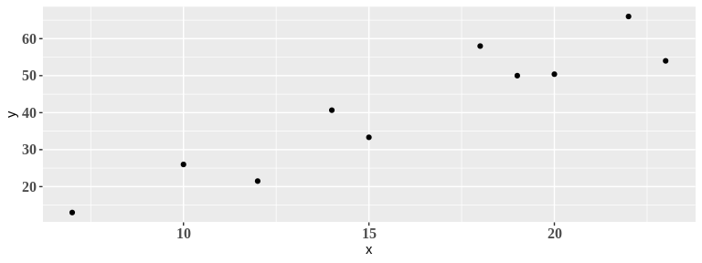

```r
set.seed(42)

cars %>%
  filter(dist < 80) %>%
  group_by(speed) %>%
  summarise(dist = mean(dist)) %>%
  sample_n(10) %>%
  ggplot(aes(x = speed, y = dist)) +
  geom_point() + labs(x = "x", y = "y") +
  theme(axis.text = element_text(family = "serif", face = "bold", size = 12))
```

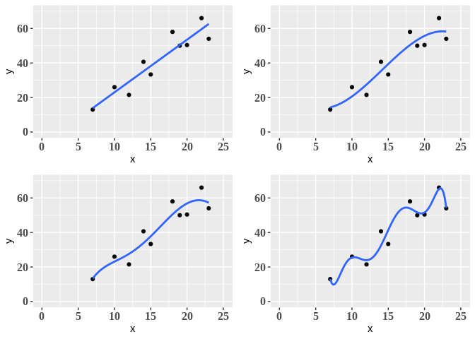

```r
set.seed(42)

plot1 <- cars %>%
  filter(dist < 80) %>%
  group_by(speed) %>%
  summarise(dist = mean(dist)) %>%
  sample_n(10) %>%
  ggplot(aes(x = speed, y = dist)) +
  geom_point() + labs(x = "x", y = "y") +
  theme(axis.text = element_text(family = "serif", face = "bold", size = 12)) +
  stat_smooth(aes(x = speed, y = dist), method = "lm",na.rm = TRUE,
              formula = y ~ poly(x, 1), se = FALSE) + xlim(0, 25) + ylim(0,70)

set.seed(42)

plot2 <- cars %>%
  filter(dist < 80) %>%
  group_by(speed) %>%
  summarise(dist = mean(dist)) %>%
  sample_n(10) %>%
  ggplot(aes(x = speed, y = dist)) +
  geom_point() + labs(x = "x", y = "y") +
  theme(axis.text = element_text(family = "serif", face = "bold", size = 12)) +
  stat_smooth(aes(x = speed, y = dist), method = "lm",na.rm = TRUE,
              formula = y ~ poly(x, 3), se = FALSE) + xlim(0, 25) + ylim(0,70)

set.seed(42)

plot3 <- cars %>%
  filter(dist < 80) %>%
  group_by(speed) %>%
  summarise(dist = mean(dist)) %>%
  sample_n(10) %>%
  ggplot(aes(x = speed, y = dist)) +
  geom_point() + labs(x = "x", y = "y") +
  theme(axis.text = element_text(family = "serif", face = "bold", size = 12)) +
  stat_smooth(aes(x = speed, y = dist), method = "lm",na.rm = TRUE,
              formula = y ~ poly(x, 5), se = FALSE) + xlim(0, 25) + ylim(0,70)

set.seed(42)

plot4 <- cars %>%
  filter(dist < 80) %>%
  group_by(speed) %>%
  summarise(dist = mean(dist)) %>%
  sample_n(10) %>%
  ggplot(aes(x = speed, y = dist)) +
  geom_point() + labs(x = "x", y = "y") +
  theme(axis.text = element_text(family = "serif", face = "bold", size = 12)) +
  stat_smooth(aes(x = speed, y = dist), method = "lm",na.rm = TRUE,
              formula = y ~ poly(x, 7), se = FALSE) + xlim(0, 25) + ylim(0,70)

grid.arrange(plot1, plot2, plot3, plot4, ncol=2)
```

Analisando os gráficos acima vemos que conforme aumentamos o grau do polinômio, ou seja, a complexidade do modelo, obtemos uma curva mais aderente aos dados - dizemos, desta forma, que conforme aumentamos a complexidade do modelo, reduzimos o bias associado ao modelo.

Esta observação se torna mais clara, se ao invés de poucos pontos, povoassemos todo o espaço da variável preditora. Neste caso, apesar do último modelo ser de grau 7, seu comportamento seria equivalente ao de uma reta, portanto, se aproximando do modelo ideal linear.

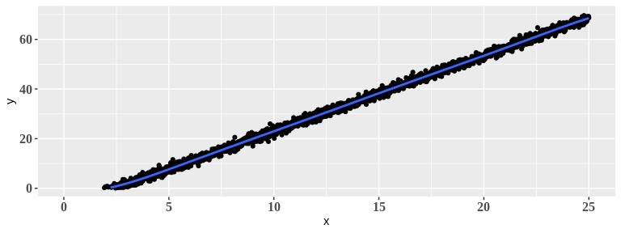

```r
set.seed(42)

dc <- cars %>%
  filter(dist < 80) %>%
  group_by(speed) %>%
  summarise(dist = mean(dist)) %>%
  sample_n(10)

lm(dist ~ speed, data = dc) %>%
  predict(data.frame(speed = seq(0,25,0.01))) %>%
  as_tibble() %>%
  rename(dist = value) %>%
  mutate(dist = dist + rnorm(length(seq(0,25,0.01))),0,0.2) %>%
  mutate(speed =  seq(0,25,0.01)) %>%
  filter(dist > 0) %>%
  ggplot(aes(x = speed, y = dist)) +
  geom_point() + labs(x = "x", y = "y") +
  theme(axis.text = element_text(family = "serif", face = "bold", size = 12)) +
  stat_smooth(aes(x = speed, y = dist), method = "lm",na.rm = TRUE,
              formula = y ~ poly(x, 7), se = FALSE) + xlim(0, 25) + ylim(0,70)
```

Experimentemos agora, gerar outros dados vindo do mesmo banco de dados `cars` e observar o comportamento dos modelos polinomiais - alteremos para `set.seed(43)` no código anterior.

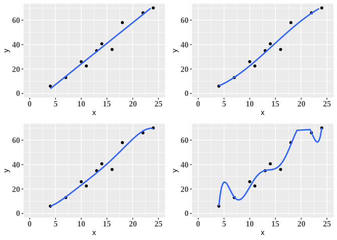

```r
set.seed(43)

plot1 <- cars %>%
  filter(dist < 80) %>%
  group_by(speed) %>%
  summarise(dist = mean(dist)) %>%
  sample_n(10) %>%
  ggplot(aes(x = speed, y = dist)) +
  geom_point() + labs(x = "x", y = "y") +
  theme(axis.text = element_text(family = "serif", face = "bold", size = 12)) +
  stat_smooth(aes(x = speed, y = dist), method = "lm",na.rm = TRUE,
              formula = y ~ poly(x, 1), se = FALSE) + xlim(0, 25) + ylim(0,70)

set.seed(43)

plot2 <- cars %>%
  filter(dist < 80) %>%
  group_by(speed) %>%
  summarise(dist = mean(dist)) %>%
  sample_n(10) %>%
  ggplot(aes(x = speed, y = dist)) +
  geom_point() + labs(x = "x", y = "y") +
  theme(axis.text = element_text(family = "serif", face = "bold", size = 12)) +
  stat_smooth(aes(x = speed, y = dist), method = "lm",na.rm = TRUE,
              formula = y ~ poly(x, 3), se = FALSE) + xlim(0, 25) + ylim(0,70)

set.seed(43)

plot3 <- cars %>%
  filter(dist < 80) %>%
  group_by(speed) %>%
  summarise(dist = mean(dist)) %>%
  sample_n(10) %>%
  ggplot(aes(x = speed, y = dist)) +
  geom_point() + labs(x = "x", y = "y") +
  theme(axis.text = element_text(family = "serif", face = "bold", size = 12)) +
  stat_smooth(aes(x = speed, y = dist), method = "lm",na.rm = TRUE,
              formula = y ~ poly(x, 5), se = FALSE) + xlim(0, 25) + ylim(0,70)

set.seed(43)

plot4 <- cars %>%
  filter(dist < 80) %>%
  group_by(speed) %>%
  summarise(dist = mean(dist)) %>%
  sample_n(10) %>%
  ggplot(aes(x = speed, y = dist)) +
  geom_point() + labs(x = "x", y = "y") +
  theme(axis.text = element_text(family = "serif", face = "bold", size = 12)) +
  stat_smooth(aes(x = speed, y = dist), method = "lm",na.rm = TRUE,
              formula = y ~ poly(x, 7), se = FALSE)  + xlim(0, 25) + ylim(0,70)

grid.arrange(plot1, plot2, plot3, plot4, ncol=2)
```

Compare o gráfico acima com o gerado anteriormente.

Observe que conforme se aumenta o grau do polinômio (complexidade do modelo) **menos** o modelo ajustado é similar ao equivalente na primeira figura - dizemos, neste caso, que a variância entre os modelo aumenta conforme a complexidade.

Com base nesta abordagem intuitiva fica claro que o bias reduz com a complexidade do modelo e o inverso ocorre com a variância. O erro irredutível é constante, e o erro esperado corresponde a soma destes três últimos termos. Estes fatos podem ser resumidos na figura a seguir, resultado de uma simulação de bias-variância que abordaremos no próximo post.

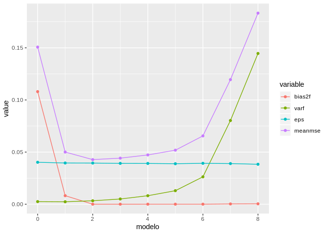